# Run-Through Example

Author

Havisha Khurana

Published

Monday, March 17, 2025

One of the data sources I worked on for the project were public documentation from the Oregon Department of Education (ODE) that detailed state funds allocation to school districts by student types. This document came in the form of structured .pdfs. The primary ‘Data Sciency’ task I undertook during the capstone was to scrape 14 pdfs of 233 pages each.

In this section, I will walkthrough an example of scraping data for one district. All these functions are found in the **code/** folder.

Let’s start by looking at one pdf page.

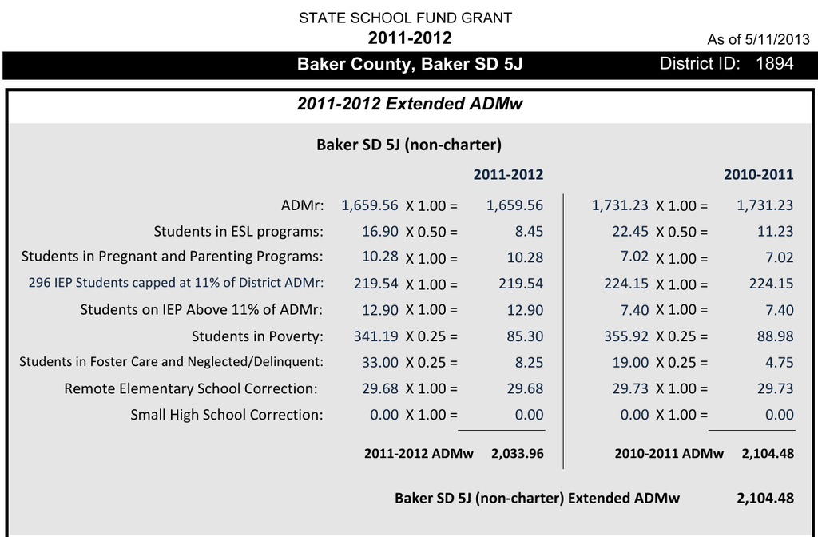

Let’s see the intermediate steps for transforming the data.

From the pdf, I get to a dataframe of each line.

Then, I create a list of 197 dataframes corresponding to informaion associated with each Oregon school district.

I classify each line leveraging the structure.

Using the line classified as **district_info**, I grabbed the district details.

The resulting dataframe for one school district after applying the regular expressions rules.

| text | page | district_id_found |
| --- | --- | --- |
| STATE SCHOOL FUND GRANT | 1 | 0 |
| 2011-2012 As of 5/11/2013 | 1 | 0 |
| Baker County, Baker SD 5J District ID: 1894 | 1 | 1 |
| 2011-2012 Extended ADMw | 1 | 0 |
| Baker SD 5J (non-charter) | 1 | 0 |
| 2011-2012 2010-2011 | 1 | 0 |
| ADMr: 1,659.56 X 1.00 = 1,659.56 1,731.23 X 1.00 = 1,731.23 | 1 | 0 |
| Students in ESL programs: 16.90 X 0.50 = 8.45 22.45 X 0.50 = 11.23 | 1 | 0 |
| Students in Pregnant and Parenting Programs: 10.28 X 1.00 = 10.28 7.02 X 1.00 = 7.02 | 1 | 0 |
| 296 IEP Students capped at 11% of District ADMr: 219.54 X 1.00 = 219.54 224.15 X 1.00 = 224.15 | 1 | 0 |

[output cut: 5492 more lines]

| text | page | district_id_found | district_index |
| --- | --- | --- | --- |
| STATE SCHOOL FUND GRANT | 1 | 0 | 1 |
| 2011-2012 As of 5/11/2013 | 1 | 0 | 1 |
| Baker County, Baker SD 5J District ID: 1894 | 1 | 1 | 1 |
| 2011-2012 Extended ADMw | 1 | 0 | 1 |
| Baker SD 5J (non-charter) | 1 | 0 | 1 |
| 2011-2012 2010-2011 | 1 | 0 | 1 |
| ADMr: 1,659.56 X 1.00 = 1,659.56 1,731.23 X 1.00 = 1,731.23 | 1 | 0 | 1 |
| Students in ESL programs: 16.90 X 0.50 = 8.45 22.45 X 0.50 = 11.23 | 1 | 0 | 1 |
| Students in Pregnant and Parenting Programs: 10.28 X 1.00 = 10.28 7.02 X 1.00 = 7.02 | 1 | 0 | 1 |
| 296 IEP Students capped at 11% of District ADMr: 219.54 X 1.00 = 219.54 224.15 X 1.00 = 224.15 | 1 | 0 | 1 |

[output cut: 38 more lines]

| text | page | information_type | entry_index |
| --- | --- | --- | --- |
| Baker County, Baker SD 5J District ID: 1894 | 1 | district_info | 0 |
| Baker SD 5J (non-charter) | 1 | entry_name | 1 |
| ADMr: 1,659.56 X 1.00 = 1,659.56 1,731.23 X 1.00 = 1,731.23 | 1 | category_info | 1 |
| Students in ESL programs: 16.90 X 0.50 = 8.45 22.45 X 0.50 = 11.23 | 1 | category_info | 1 |
| Students in Pregnant and Parenting Programs: 10.28 X 1.00 = 10.28 7.02 X 1.00 = 7.02 | 1 | category_info | 1 |
| 296 IEP Students capped at 11% of District ADMr: 219.54 X 1.00 = 219.54 224.15 X 1.00 = 224.15 | 1 | category_info | 1 |
| Students on IEP Above 11% of ADMr: 12.90 X 1.00 = 12.90 7.40 X 1.00 = 7.40 | 1 | category_info | 1 |
| Students in Poverty: 341.19 X 0.25 = 85.30 355.92 X 0.25 = 88.98 | 1 | category_info | 1 |
| Students in Foster Care and Neglected/Delinquent: 33.00 X 0.25 = 8.25 19.00 X 0.25 = 4.75 | 1 | category_info | 1 |
| Remote Elementary School Correction: 29.68 X 1.00 = 29.68 29.73 X 1.00 = 29.73 | 1 | category_info | 1 |

[output cut: 28 more lines]

```
     [,1]                                          [,2]           [,3]
[1,] "Baker County, Baker SD 5J District ID: 1894" "Baker County" "Baker SD 5J"
     [,4]
[1,] "1894"
```

| org_text | category | current_year_adm | category_weight | current_year_admw | past_year_adm | past_year_admw | entry_name | entry_index | district_geo | district_name | district_id | current_year_adm_district | current_year_admw_district | past_year_adm_district | past_year_admw_district | current_year_adm_entry | current_year_admw_entry | past_year_adm_entry | past_year_admw_entry | current_year_effective_admw_entry | current_weight_entry | current_year_eff_admw_district | current_year_extra_weight_district | current_weight_district |
| --- | --- | --- | --- | --- | --- | --- | --- | --- | --- | --- | --- | --- | --- | --- | --- | --- | --- | --- | --- | --- | --- | --- | --- | --- |
| ADMr: 1,659.56 X 1.00 = 1,659.56 1,731.23 X 1.00 = 1,731.23 | ADMr | 1659.56 | 1.00 | 1659.56 | 1731.23 | 1731.23 | Baker SD 5J (non-charter) | 1 | Baker County | Baker SD 5J | 1894 | 1995.81 | 2393.96 | 2037.69 | 2429.03 | 1659.56 | 2033.96 | 1731.23 | 2104.49 | 2104.49 | 0 | 2464.49 | 468.68 | 0 |
| Students in ESL programs: 16.90 X 0.50 = 8.45 22.45 X 0.50 = 11.23 | Students in ESL programs | 16.90 | 0.50 | 8.45 | 22.45 | 11.23 | Baker SD 5J (non-charter) | 1 | Baker County | Baker SD 5J | 1894 | 1995.81 | 2393.96 | 2037.69 | 2429.03 | 1659.56 | 2033.96 | 1731.23 | 2104.49 | 2104.49 | 0 | 2464.49 | 468.68 | 0 |
| Students in Pregnant and Parenting Programs: 10.28 X 1.00 = 10.28 7.02 X 1.00 = 7.02 | Students in Pregnant and Parenting Programs | 10.28 | 1.00 | 10.28 | 7.02 | 7.02 | Baker SD 5J (non-charter) | 1 | Baker County | Baker SD 5J | 1894 | 1995.81 | 2393.96 | 2037.69 | 2429.03 | 1659.56 | 2033.96 | 1731.23 | 2104.49 | 2104.49 | 0 | 2464.49 | 468.68 | 0 |
| 296 IEP Students capped at 11% of District ADMr: 219.54 X 1.00 = 219.54 224.15 X 1.00 = 224.15 | 296 IEP Students capped at 11% of District ADMr | 219.54 | 1.00 | 219.54 | 224.15 | 224.15 | Baker SD 5J (non-charter) | 1 | Baker County | Baker SD 5J | 1894 | 1995.81 | 2393.96 | 2037.69 | 2429.03 | 1659.56 | 2033.96 | 1731.23 | 2104.49 | 2104.49 | 0 | 2464.49 | 468.68 | 0 |
| Students on IEP Above 11% of ADMr: 12.90 X 1.00 = 12.90 7.40 X 1.00 = 7.40 | Students on IEP Above 11% of ADMr | 12.90 | 1.00 | 12.90 | 7.40 | 7.40 | Baker SD 5J (non-charter) | 1 | Baker County | Baker SD 5J | 1894 | 1995.81 | 2393.96 | 2037.69 | 2429.03 | 1659.56 | 2033.96 | 1731.23 | 2104.49 | 2104.49 | 0 | 2464.49 | 468.68 | 0 |
| Students in Poverty: 341.19 X 0.25 = 85.30 355.92 X 0.25 = 88.98 | Students in Poverty | 341.19 | 0.25 | 85.30 | 355.92 | 88.98 | Baker SD 5J (non-charter) | 1 | Baker County | Baker SD 5J | 1894 | 1995.81 | 2393.96 | 2037.69 | 2429.03 | 1659.56 | 2033.96 | 1731.23 | 2104.49 | 2104.49 | 0 | 2464.49 | 468.68 | 0 |
| Students in Foster Care and Neglected/Delinquent: 33.00 X 0.25 = 8.25 19.00 X 0.25 = 4.75 | Students in Foster Care and Neglected/Delinquent | 33.00 | 0.25 | 8.25 | 19.00 | 4.75 | Baker SD 5J (non-charter) | 1 | Baker County | Baker SD 5J | 1894 | 1995.81 | 2393.96 | 2037.69 | 2429.03 | 1659.56 | 2033.96 | 1731.23 | 2104.49 | 2104.49 | 0 | 2464.49 | 468.68 | 0 |
| Remote Elementary School Correction: 29.68 X 1.00 = 29.68 29.73 X 1.00 = 29.73 | Remote Elementary School Correction | 29.68 | 1.00 | 29.68 | 29.73 | 29.73 | Baker SD 5J (non-charter) | 1 | Baker County | Baker SD 5J | 1894 | 1995.81 | 2393.96 | 2037.69 | 2429.03 | 1659.56 | 2033.96 | 1731.23 | 2104.49 | 2104.49 | 0 | 2464.49 | 468.68 | 0 |
| Small High School Correction: 0.00 X 1.00 = 0.00 0.00 X 1.00 = 0.00 | Small High School Correction | 0.00 | 1.00 | 0.00 | 0.00 | 0.00 | Baker SD 5J (non-charter) | 1 | Baker County | Baker SD 5J | 1894 | 1995.81 | 2393.96 | 2037.69 | 2429.03 | 1659.56 | 2033.96 | 1731.23 | 2104.49 | 2104.49 | 0 | 2464.49 | 468.68 | 0 |
| ADMr: 287.00 X 1.00 = 287.00 286.48 X 1.00 = 286.48 | ADMr | 287.00 | 1.00 | 287.00 | 286.48 | 286.48 | Baker Web Academy | 2 | Baker County | Baker SD 5J | 1894 | 1995.81 | 2393.96 | 2037.69 | 2429.03 | 287.00 | 308.22 | 286.48 | 303.53 | 308.22 | 0 | 2464.49 | 468.68 | 0 |

[output cut: 17 more lines]

*And then repeating it over across all districts, and all years.*